# Tutorial 4: Multivariate (Multi-Trait) Analysis

QGM team

16:37:25 on 22 January, 2026

# 1 Introduction

In this tutorial we will fit multivariate models. These models are important as they use relationships between traits to enable prediction of one trait to be made from another trait. Sometimes there is rich information on one trait either because it is easily collected, or a phenotype has a high heritability (i.e. the phenotype is rich in genetic information), while others are hard to measure and low heritability making accuracy poor. The idea allows some different approaches to other problems, e.g. measures at different ages can be regarded as different traits, or a trait in males and a trait in females. In summary multivariate models are powerful tools in quantitative genetic models.

Everything done in previous tutorials applies - PTAs, EBVs, Wald tests, Likelihood Ratio tests. There are two challenges with multivariate models.

1. The first challenge is the mental challenge to keep track of parameters as parameters increase as $n^2$ for $n$ traits. There are $0.5 n(n+1)$ parameters for just one random effect, $n$ trait variances and $0.5 n(n-1)$ covariances or correlations among traits; so parameter lists get longer and hypotheses tend to multiply.
2. The second challenge is the the extra syntax in the `asreml()` call.

# 2 Setting up

Load the libraries and qgm functions needed - again there are no new helper functions.

```r
library("asreml")
source("qgm_helpers_t4.R")
```

Two further libraries are loaded to help explore the data.

```r
library("ggplot2")
library("GGally")
```

# 3 Reading data and pedigree

## 3.1 Records

The data is changed somewhat from Tutorials 1 to 3. The traits here will be the body weight (`bwt`) of the Silver Carp at an important management point in the growth period (in g), the fillet weight (`fwt`) at the end of the growth (g), and the Minolta lightness (L*) of the fillet colour (`minl` with no units). The generations have again been made overlapping.

```r
tut4 <- read.csv(file="rdat4.csv", header=TRUE, na.strings=c("NA"))
head(tut4)
```

```
##   id sire dam gen sex tank   bwt   fwt  minl period
## 1  1    0   0   0   1    4 196.4 214.9 630.2      0
## 2  2    0   0   0   2    2 145.6  97.3 628.4      1
## 3  3    0   0   0   1    1 140.9 175.2 584.0      0
## 4  4    0   0   0   2    3  91.6 117.2 615.1      0
## 5  5    0   0   0   1    3 127.2 107.4 626.8      0
## 6  6    0   0   0   2    4 185.9 154.1 554.1      0
```

```r
tail(tut4)
```

```
##        id sire  dam gen sex tank   bwt   fwt  minl period
## 4395 4395 3905 3924  10   1    3 257.6 182.8 665.6     10
## 4396 4396 3905 3924  10   2    3 247.7 129.3 563.2     10
## 4397 4397 3905 3924  10   1    3 219.0 139.7 651.9     11
## 4398 4398 3905 3924  10   2    4 252.8 174.5 629.9     10
## 4399 4399 3905 3924  10   1    4 248.8 170.2 610.5     10
## 4400 4400 3905 3924  10   2    3 246.9 136.1 634.4     11
```

```r
addmargins(table(tut4$gen,tut4$period))
```

```
##
##          0    1    2    3    4    5    6    7    8    9   10   11  Sum
##   0    217  183    0    0    0    0    0    0    0    0    0    0  400
##   1      0  198  202    0    0    0    0    0    0    0    0    0  400
##   2      0    0  183  217    0    0    0    0    0    0    0    0  400
##   3      0    0    0  191  209    0    0    0    0    0    0    0  400
##   4      0    0    0    0  182  218    0    0    0    0    0    0  400
##   5      0    0    0    0    0  190  210    0    0    0    0    0  400
##   6      0    0    0    0    0    0  195  205    0    0    0    0  400
##   7      0    0    0    0    0    0    0  197  203    0    0    0  400
##   8      0    0    0    0    0    0    0    0  192  208    0    0  400
##   9      0    0    0    0    0    0    0    0    0  201  199    0  400
##   10     0    0    0    0    0    0    0    0    0    0  207  193  400
##   Sum  217  381  385  408  391  408  405  402  395  409  406  193 4400
```

### 3.1.1 Repeated records?

One question that should always be asked is whether there are repeated records in the data. If there are these will need to catered for in the model! This information can be easily obtained using `qgm_ped_summary()` with the first 3 columns.

```r
qgm_ped_summary(tut4[,1:3])
```

```
## [1] "Pedigree assumed ordered id, sire, dam in columns 1 to 3"
## [1] "Number of distinct ids: 4400"
## [1] " ... Maximum number of records per id: 1"
## [1] " ... Minimum number of records per id: 1"
## [1] " ... Number of distinct ids with no sire: 400"
## [1] " ... Number of distinct ids with no dam : 400"
## [1] " ... Number of distinct ids with no sire or dam: 400"
## [1] "Number of distinct sires: 100"
## [1] " ... Maximum offspring per sire : 40"
## [1] " ... Minimum offspring per sire : 40"
## [1] "Number of distinct dams : 500"
## [1] " ... Maximum offspring per dam : 8"
## [1] " ... Minimum offspring per dam : 8"
## [1] "Number of mating pairs: 500"
## [1] " ... Maximum number of sires per dam: 1"
## [1] " ... Minimum number of sires per dam: 1"
## [1] " ... Maximum number of dams per sire: 5"
## [1] " ... Minimum number of dams per sire: 5"
## [1] " ... Maximum number of offspring per pair: 8"
## [1] " ... Minimum number of offspring per pair: 8"
## [1] "Number of parents used as both sires and dams: 0"
## [1] "Number of parents used for selfing: 0"
```

Every individual only has 1 record - which makes the model simpler! Again for simplicity we shall assume here that we know from previous analyses that these traits have no maternal effects although this does not add greatly to setting up the model, but output lists become longer!

### 3.1.2 Exploring data

Good exploration of multiple traits requires getting some idea about how the traits relate to each other as well as an indication of their distribution. This can be quite tricky with lots of traits. A useful approach is a ‘trellis plot’. This uses the `ggplot2` and `GGally` packages and you may wish to remember it in future. In QGM if required the basic code will be provided. It provides very crude shapes of distributions, simple pair-wise correlations and pair-wise scatter plots. This is very basic e.g. for example there are many generations of data all mixed up together!

- When plotting many points in a plot (e.g. in MSc projects!) beware uninformative ‘blot plots’ which simply show a big black blotch - they are rarely helpful. In R you can change point size and transparency (often using a parameter called ‘alpha’) to illuminate structure.
- The trellis plot does not show any problems that will require special attention.

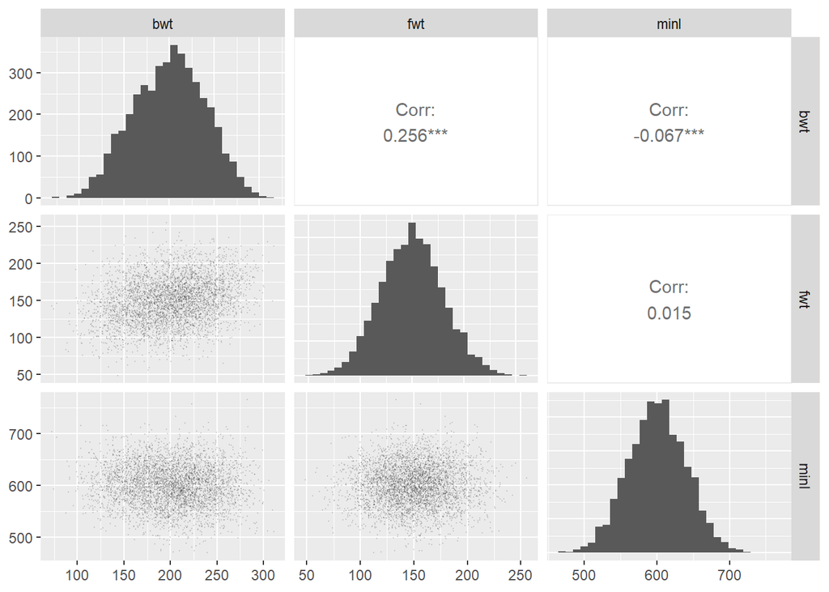

```r
ggpairs(data = tut4[,c("bwt","fwt","minl")], diag= list(continuous= "bar", binwidth= 30), lower= list(continuous= wrap(ggally_points, size= 0.01, alpha= 0.1)))
```

## 3.2 Pedigree

The pedigree is the same as previously, but with a simple change that the `0` code for unknown, commonly used in pedigree files, has been replaced by `NA` for unknown. This makes no difference in R.

```r
ped <- read.csv(file= "rped4.csv", header= TRUE, na.strings=c("NA"))
head(ped)
```

```
##   id sire dam gen sex
## 1  1   NA  NA   0   1
## 2  2   NA  NA   0   2
## 3  3   NA  NA   0   1
## 4  4   NA  NA   0   2
## 5  5   NA  NA   0   1
## 6  6   NA  NA   0   2
```

```r
tail(ped)
```

```
##        id sire  dam gen sex
## 4395 4395 3905 3924  10   1
## 4396 4396 3905 3924  10   2
## 4397 4397 3905 3924  10   1
## 4398 4398 3905 3924  10   2
## 4399 4399 3905 3924  10   1
## 4400 4400 3905 3924  10   2
```

## 3.3 Question 1

- Q1. Explore the data. This should include something about fixed effects that may need to be accounted for, and summaries of the genetic structure in a typical generation, giving some simple information indicating how useful the data may be to estimate genetic parameters.
  - Look back at previous tutorials for code snippets - I regularly do!
- $\mathbf{Answer.}$ Here are some relevant points:
  - Prospective fixed effects .
    - The data has representatives from 11 consecutive generations well balanced.
    - Each generation is represented in 2 of the 12 periods, removing the possibility of complete confounding of generations with time - periods also being approximately equal.
    - There are also balanced sexes, and approximately balanced tanks.
    - However genetic change is to be captured by a fitting a pedigree term, and period accounts for the time trend - so generation will not be fitted in the model. Otherwise sex, tank are fixed effects for the model.
- The `qgm_ped_summary()` with the data file also shows that individuals do not have repeated records, so there will be no opportunity to capture permanent environment - it will drop into the residual. The lack of repeated records (and/or other information) means that there are no information on age or stage of development (or whatever is relevant) for the record.
- The genetic structure appears (from a sample of generations) appears to be constant and well balanced. Each generation is produced from 10 sires, and 50 dams, with hierarchical mating, each sire mated to exactly 5 dams, and each dam to just the 1 sire. Full-sib family sizes were also equal in size. Therefore the 400 individuals in each generation had 50 full sib family each of 8 offspring, with sires having a total of 40 offspring. For a pedigree analysis this is quite good allowing good estimates of sire means, possibly dam means, with a good number of sires (especially over generations) to estimate variances. Since the analysis is intended for estimating genetic correlations, there is a need to have strong genetic signals for a good sample of individuals - it is hard to estimate genetic correlations on a small sample of weak estimates of breeding values. Remember genetic correlations are correlations of breeding values - so first find your breeding values!
- In a bivariate analysis it is relevant how much information is on each trait. Each individual has both traits, with no missing values, so there will be environmental correlations as well as genetic correlations.

```r
addmargins(table(tut4$sex, tut4$tank))
```

```
##
##          1    2    3    4  Sum
##   1    550  557  551  542 2200
##   2    557  539  542  562 2200
##   Sum 1107 1096 1093 1104 4400
```

```r
addmargins(table(tut4$sex, tut4$gen))
```

```
##
##          0    1    2    3    4    5    6    7    8    9   10  Sum
##   1    200  200  200  200  200  200  200  200  200  200  200 2200
##   2    200  200  200  200  200  200  200  200  200  200  200 2200
##   Sum  400  400  400  400  400  400  400  400  400  400  400 4400
```

```r
addmargins(table(tut4$tank, tut4$gen))
```

```
##
##          0    1    2    3    4    5    6    7    8    9   10  Sum
##   1    108  103   97   96  107  113   96  109   90   90   98 1107
##   2    109  101   84  105   94  102  117   98  100   93   93 1096
##   3     81   91  105  116  101   79   86  100  104  124  106 1093
##   4    102  105  114   83   98  106  101   93  106   93  103 1104
##   Sum  400  400  400  400  400  400  400  400  400  400  400 4400
```

```r
addmargins(table(tut4$sex, tut4$period))
```

```
##
##          0    1    2    3    4    5    6    7    8    9   10   11  Sum
##   1    104  190  194  216  191  202  203  207  186  210  198   99 2200
##   2    113  191  191  192  200  206  202  195  209  199  208   94 2200
##   Sum  217  381  385  408  391  408  405  402  395  409  406  193 4400
```

```r
addmargins(table(tut4$tank, tut4$period))
```

```
##
##          0    1    2    3    4    5    6    7    8    9   10   11  Sum
##   1     56   97  100  100  104  109  105  100  102   89   95   50 1107
##   2     57   99   90   92  108   94  107  117   91   93  105   43 1096
##   3     47   76  102  106  103   97   93   85  104  117  114   49 1093
##   4     57  109   93  110   76  108  100  100   98  110   92   51 1104
##   Sum  217  381  385  408  391  408  405  402  395  409  406  193 4400
```

```r
qgm_ped_summary(tut4[tut4$gen %in% c(0),]) # base generation
```

```
## [1] "Pedigree assumed ordered id, sire, dam in columns 1 to 3"
## [1] "Number of distinct ids: 400"
## [1] " ... Maximum number of records per id: 1"
## [1] " ... Minimum number of records per id: 1"
## [1] " ... Number of distinct ids with no sire: 400"
## [1] " ... Number of distinct ids with no dam : 400"
## [1] " ... Number of distinct ids with no sire or dam: 400"
## [1] "Number of distinct sires: 0"
## [1] "Number of distinct dams : 0"
## [1] "Number of mating pairs: 0"
```

```r
qgm_ped_summary(tut4[tut4$gen %in% c(1),]) # some interesting generations
```

```
## [1] "Pedigree assumed ordered id, sire, dam in columns 1 to 3"
## [1] "Number of distinct ids: 400"
## [1] " ... Maximum number of records per id: 1"
## [1] " ... Minimum number of records per id: 1"
## [1] " ... Number of distinct ids with no sire: 0"
## [1] " ... Number of distinct ids with no dam : 0"
## [1] " ... Number of distinct ids with no sire or dam: 0"
## [1] "Number of distinct sires: 10"
## [1] " ... Maximum offspring per sire : 40"
## [1] " ... Minimum offspring per sire : 40"
## [1] "Number of distinct dams : 50"
## [1] " ... Maximum offspring per dam : 8"
## [1] " ... Minimum offspring per dam : 8"
## [1] "Number of mating pairs: 50"
## [1] " ... Maximum number of sires per dam: 1"
## [1] " ... Minimum number of sires per dam: 1"
## [1] " ... Maximum number of dams per sire: 5"
## [1] " ... Minimum number of dams per sire: 5"
## [1] " ... Maximum number of offspring per pair: 8"
## [1] " ... Minimum number of offspring per pair: 8"
## [1] "Number of parents used as both sires and dams: 0"
## [1] "Number of parents used for selfing: 0"
```

```r
qgm_ped_summary(tut4[tut4$gen %in% c(6),])
```

```
## [1] "Pedigree assumed ordered id, sire, dam in columns 1 to 3"
## [1] "Number of distinct ids: 400"
## [1] " ... Maximum number of records per id: 1"
## [1] " ... Minimum number of records per id: 1"
## [1] " ... Number of distinct ids with no sire: 0"
## [1] " ... Number of distinct ids with no dam : 0"
## [1] " ... Number of distinct ids with no sire or dam: 0"
## [1] "Number of distinct sires: 10"
## [1] " ... Maximum offspring per sire : 40"
## [1] " ... Minimum offspring per sire : 40"
## [1] "Number of distinct dams : 50"
## [1] " ... Maximum offspring per dam : 8"
## [1] " ... Minimum offspring per dam : 8"
## [1] "Number of mating pairs: 50"
## [1] " ... Maximum number of sires per dam: 1"
## [1] " ... Minimum number of sires per dam: 1"
## [1] " ... Maximum number of dams per sire: 5"
## [1] " ... Minimum number of dams per sire: 5"
## [1] " ... Maximum number of offspring per pair: 8"
## [1] " ... Minimum number of offspring per pair: 8"
## [1] "Number of parents used as both sires and dams: 0"
## [1] "Number of parents used for selfing: 0"
```

```r
qgm_ped_summary(tut4[tut4$gen %in% c(7),])
```

```
## [1] "Pedigree assumed ordered id, sire, dam in columns 1 to 3"
## [1] "Number of distinct ids: 400"
## [1] " ... Maximum number of records per id: 1"
## [1] " ... Minimum number of records per id: 1"
## [1] " ... Number of distinct ids with no sire: 0"
## [1] " ... Number of distinct ids with no dam : 0"
## [1] " ... Number of distinct ids with no sire or dam: 0"
## [1] "Number of distinct sires: 10"
## [1] " ... Maximum offspring per sire : 40"
## [1] " ... Minimum offspring per sire : 40"
## [1] "Number of distinct dams : 50"
## [1] " ... Maximum offspring per dam : 8"
## [1] " ... Minimum offspring per dam : 8"
## [1] "Number of mating pairs: 50"
## [1] " ... Maximum number of sires per dam: 1"
## [1] " ... Minimum number of sires per dam: 1"
## [1] " ... Maximum number of dams per sire: 5"
## [1] " ... Minimum number of dams per sire: 5"
## [1] " ... Maximum number of offspring per pair: 8"
## [1] " ... Minimum number of offspring per pair: 8"
## [1] "Number of parents used as both sires and dams: 0"
## [1] "Number of parents used for selfing: 0"
```

```r
qgm_ped_summary(tut4[tut4$gen %in% c(10),])
```

```
## [1] "Pedigree assumed ordered id, sire, dam in columns 1 to 3"
## [1] "Number of distinct ids: 400"
## [1] " ... Maximum number of records per id: 1"
## [1] " ... Minimum number of records per id: 1"
## [1] " ... Number of distinct ids with no sire: 0"
## [1] " ... Number of distinct ids with no dam : 0"
## [1] " ... Number of distinct ids with no sire or dam: 0"
## [1] "Number of distinct sires: 10"
## [1] " ... Maximum offspring per sire : 40"
## [1] " ... Minimum offspring per sire : 40"
## [1] "Number of distinct dams : 50"
## [1] " ... Maximum offspring per dam : 8"
## [1] " ... Minimum offspring per dam : 8"
## [1] "Number of mating pairs: 50"
## [1] " ... Maximum number of sires per dam: 1"
## [1] " ... Minimum number of sires per dam: 1"
## [1] " ... Maximum number of dams per sire: 5"
## [1] " ... Minimum number of dams per sire: 5"
## [1] " ... Maximum number of offspring per pair: 8"
## [1] " ... Minimum number of offspring per pair: 8"
## [1] "Number of parents used as both sires and dams: 0"
## [1] "Number of parents used for selfing: 0"
```

```r
addmargins(table(is.na(tut4$bwt),is.na(tut4$fwt)))
```

```
##
##         FALSE  Sum
##   FALSE  4400 4400
##   Sum    4400 4400
```

# 4 Declaring factors

We will need to set up the following as factors: `sex`, `tank` and `period` are fixed, `id` will be random.

```r
tut4$sex <- factor(tut4$sex)
tut4$tank <- factor(tut4$tank)
tut4$period <- factor(tut4$period)
tut4$id <- factor(tut4$id)
```

# 5 Obtaining A-inverse

Easy!

```r
ainv <- ainverse(ped[,1:3])
```

# 6 Fitting a multi-trait (multivariate) model

## 6.1 Defining the model

The same basic format of setting up the model is retained: `fixed=`, `random=`, and `residual=`, but we need to develop the way we present the model. See the code chunk below. For simplicity we are only running a bivariate model.

- the `fixed=` term
  - y-variates: to show the multiple traits we simply list them with `cbind()`, which in R binds columns together;
  - mean: we now have a mean for each trait, so rather than `1` we put `trait`;
  - factors: we now have fixed effects for each trait, so e.g. rather than `sex` we put `trait:sex`;
    - note the ‘:’ not ‘.’, which some packages use;
- the `random=` term
  - each term is of the form ‘something about the traits’:‘variance model for the factor’, where the variance model for the factor is familiar from previous tutorials;
  - the ‘something about the traits’ is another variance model describing the (co)variances among the traits for that factor, and in the code chunk below it is given by `us()`;
    - the `us()` is for an unstructured and model, where with $n$ traits one simply fits a general $n$x$n$ (co)variance matrix;
- the `residual=` term … sadly, for reasons unknown to me … there are annoying little changes!
  - firstly ‘something about the traits’ comes after ‘variance model for units’, NOT before(!);
  - secondly the ‘identity matrix’ covariance matrix is now ‘id(units)’ not ‘idv(units)’ (which is messy!).

```r
tut4.asr <- asreml(fixed=cbind(bwt,fwt)~trait+trait:sex+trait:tank+trait:period,random=~us(trait):vm(id,ainv),residual=~id(units):us(trait),data=tut4)
```

## 6.2 Looking at multi-trait output

Still use `qgm_summary()`.

```r
qgm_summary(tut4.asr)
```

```
## [1] "CONVERGENCE: TRUE with logL = -32570.7303883124"
##
## [1] "VARIANCE COMPONENTS"
##
##
## |                                 | component| std.error|   z.ratio|bound | %ch|
## |:--------------------------------|---------:|---------:|---------:|:-----|---:|
## |trait:vm(id, ainv)!trait_bwt:bwt | 189.06126|  21.13096|  8.947122|P     |   0|
## |trait:vm(id, ainv)!trait_fwt:bwt |  44.79023|  18.55980|  2.413292|P     |   0|
## |trait:vm(id, ainv)!trait_fwt:fwt | 207.36002|  30.68130|  6.758516|P     |   0|
## |units:trait!R                    |   1.00000|        NA|        NA|F     |   0|
## |units:trait!trait_bwt:bwt        | 406.96830|  14.35898| 28.342426|P     |   0|
## |units:trait!trait_fwt:bwt        | 163.11494|  13.12586| 12.426993|P     |   0|
## |units:trait!trait_fwt:fwt        | 636.78439|  22.09315| 28.822707|P     |   0|
##
## [1] "FIXED EFFECTS"
##
##
## |                    |    solution| std error|     z.ratio|
## |:-------------------|-----------:|---------:|-----------:|
## |trait_bwt           | 142.7336909| 1.7756587|  80.3835177|
## |trait_fwt           | 143.6467917| 2.1269504|  67.5365035|
## |trait_bwt:sex_1     |   0.0000000|        NA|          NA|
## |trait_bwt:sex_2     |   7.4996432| 0.6732449|  11.1395467|
## |trait_fwt:sex_1     |   0.0000000|        NA|          NA|
## |trait_fwt:sex_2     | -12.8199611| 0.8191000| -15.6512771|
## |trait_bwt:tank_1    |   0.0000000|        NA|          NA|
## |trait_bwt:tank_2    |   6.3621447| 0.9619734|   6.6136386|
## |trait_bwt:tank_3    |  -7.5535585| 0.9649952|  -7.8275610|
## |trait_bwt:tank_4    |  -3.4422143| 0.9643270|  -3.5695509|
## |trait_fwt:tank_1    |   0.0000000|        NA|          NA|
## |trait_fwt:tank_2    |   6.4213358| 1.1701399|   5.4876648|
## |trait_fwt:tank_3    |  -8.9158916| 1.1737749|  -7.5959127|
## |trait_fwt:tank_4    |   6.0803049| 1.1725412|   5.1855789|
## |trait_bwt:period_0  |   0.0000000|        NA|          NA|
## |trait_bwt:period_1  |  -0.5856472| 2.1471780|  -0.2727520|
## |trait_bwt:period_2  |  -1.7735301| 2.5213942|  -0.7033927|
## |trait_bwt:period_3  |  -2.1731485| 2.9014348|  -0.7489910|
## |trait_bwt:period_4  |  -2.5732154| 3.2242646|  -0.7980782|
## |trait_bwt:period_5  |  -5.2258247| 3.5104985|  -1.4886275|
```

[output cut: 13 more lines]

```
## |trait_fwt:period_7  |  -2.1067052| 4.7647404|  -0.4421448|
## |trait_fwt:period_8  |  -1.6652340| 5.0250220|  -0.3313884|
## |trait_fwt:period_9  |  -2.4384230| 5.2878169|  -0.4611398|
## |trait_fwt:period_10 |   0.0734496| 5.5479168|   0.0132391|
## |trait_fwt:period_11 |  -1.5363596| 5.8833864|  -0.2611352|
##
## [1] "WALD TESTS"
##
##
## |             | Df|  denDF|     F.con|Pr     |
## |:------------|--:|------:|---------:|:------|
## |trait        |  2| 1171.6| 1.072e+04|0.0000 |
## |trait:sex    |  2| 4260.5| 2.621e+02|0.0000 |
## |trait:tank   |  6| 5706.9| 6.381e+01|0.0000 |
## |trait:period | 22| 5665.1| 9.642e-01|0.5078 |
```

- Sensible fit? Convergence looks good, all terms have ‘P’, and ‘%ch’ are all zero. If the components were still showing small changes or iterations looked to be converging but not quite there then there is a function `qgm_continue()` to update the analysis with a few more iterations. Note its usage.

```r
tut4.asr <- qgm_continue(tut4.asr,5)
qgm_summary(tut4.asr)
```

```
## [1] "CONVERGENCE: TRUE with logL = -32570.7303883104"
##
## [1] "VARIANCE COMPONENTS"
##
##
## |                                 | component| std.error|   z.ratio|bound | %ch|
## |:--------------------------------|---------:|---------:|---------:|:-----|---:|
## |trait:vm(id, ainv)!trait_bwt:bwt | 189.06105|  21.13106|  8.947068|P     |   0|
## |trait:vm(id, ainv)!trait_fwt:bwt |  44.79005|  18.55995|  2.413264|P     |   0|
## |trait:vm(id, ainv)!trait_fwt:fwt | 207.36003|  30.68154|  6.758461|P     |   0|
## |units:trait!R                    |   1.00000|        NA|        NA|F     |   0|
## |units:trait!trait_bwt:bwt        | 406.96841|  14.35899| 28.342404|P     |   0|
## |units:trait!trait_fwt:bwt        | 163.11504|  13.12588| 12.426978|P     |   0|
## |units:trait!trait_fwt:fwt        | 636.78439|  22.09320| 28.822645|P     |   0|
##
## [1] "FIXED EFFECTS"
##
##
## |                    |    solution| std error|     z.ratio|
## |:-------------------|-----------:|---------:|-----------:|
## |trait_bwt           | 142.7336927| 1.7756592|  80.3834957|
## |trait_fwt           | 143.6467940| 2.1269512|  67.5364780|
## |trait_bwt:sex_1     |   0.0000000|        NA|          NA|
## |trait_bwt:sex_2     |   7.4996436| 0.6732449|  11.1395482|
## |trait_fwt:sex_1     |   0.0000000|        NA|          NA|
## |trait_fwt:sex_2     | -12.8199606| 0.8190999| -15.6512790|
## |trait_bwt:tank_1    |   0.0000000|        NA|          NA|
## |trait_bwt:tank_2    |   6.3621445| 0.9619734|   6.6136390|
## |trait_bwt:tank_3    |  -7.5535595| 0.9649951|  -7.8275627|
## |trait_bwt:tank_4    |  -3.4422144| 0.9643269|  -3.5695513|
## |trait_fwt:tank_1    |   0.0000000|        NA|          NA|
## |trait_fwt:tank_2    |   6.4213355| 1.1701398|   5.4876654|
## |trait_fwt:tank_3    |  -8.9158933| 1.1737747|  -7.5959151|
## |trait_fwt:tank_4    |   6.0803047| 1.1725410|   5.1855794|
## |trait_bwt:period_0  |   0.0000000|        NA|          NA|
## |trait_bwt:period_1  |  -0.5856761| 2.1471789|  -0.2727654|
## |trait_bwt:period_2  |  -1.7735983| 2.5213957|  -0.7034193|
## |trait_bwt:period_3  |  -2.1732428| 2.9014367|  -0.7490230|
## |trait_bwt:period_4  |  -2.5733332| 3.2242668|  -0.7981142|
## |trait_bwt:period_5  |  -5.2259617| 3.5105011|  -1.4886655|
```

[output cut: 13 more lines]

```
## |trait_fwt:period_7  |  -2.1070033| 4.7647474|  -0.4422067|
## |trait_fwt:period_8  |  -1.6655685| 5.0250298|  -0.3314545|
## |trait_fwt:period_9  |  -2.4387936| 5.2878254|  -0.4612092|
## |trait_fwt:period_10 |   0.0730367| 5.5479257|   0.0131647|
## |trait_fwt:period_11 |  -1.5367944| 5.8833954|  -0.2612088|
##
## [1] "WALD TESTS"
##
##
## |             | Df|  denDF|     F.con|Pr     |
## |:------------|--:|------:|---------:|:------|
## |trait        |  2| 1171.6| 1.072e+04|0.0000 |
## |trait:sex    |  2| 4260.5| 2.621e+02|0.0000 |
## |trait:tank   |  6| 5706.9| 6.381e+01|0.0000 |
## |trait:period | 22| 5665.1| 9.642e-01|0.5078 |
```

Look at the outputs again. We will deal with the fit and fixed effects first as these are more familiar.

### 6.2.1 Questions 2 to 6

```r
at.asr <- asreml(fixed=cbind(bwt,fwt)~trait+trait:sex+trait:tank+at(trait,1):period+at(trait,2):period,random=~us(trait):vm(id,ainv),residual=~id(units):us(trait),data=tut4)
qgm_summary(at.asr)
```

```
## [1] "CONVERGENCE: TRUE with logL = -32570.7303883135"
##
## [1] "VARIANCE COMPONENTS"
##
##
## |                                 | component| std.error|   z.ratio|bound | %ch|
## |:--------------------------------|---------:|---------:|---------:|:-----|---:|
## |trait:vm(id, ainv)!trait_bwt:bwt | 189.06126|  21.13096|  8.947122|P     |   0|
## |trait:vm(id, ainv)!trait_fwt:bwt |  44.79023|  18.55980|  2.413292|P     |   0|
## |trait:vm(id, ainv)!trait_fwt:fwt | 207.36002|  30.68130|  6.758516|P     |   0|
## |units:trait!R                    |   1.00000|        NA|        NA|F     |   0|
## |units:trait!trait_bwt:bwt        | 406.96830|  14.35898| 28.342426|P     |   0|
## |units:trait!trait_fwt:bwt        | 163.11494|  13.12586| 12.426993|P     |   0|
## |units:trait!trait_fwt:fwt        | 636.78439|  22.09315| 28.822707|P     |   0|
##
## [1] "FIXED EFFECTS"
##
##
## |                           |    solution| std error|     z.ratio|
## |:--------------------------|-----------:|---------:|-----------:|
## |trait_bwt                  | 142.7336909| 1.7756587|  80.3835178|
## |trait_fwt                  | 143.6467917| 2.1269504|  67.5365035|
## |trait_bwt:sex_1            |   0.0000000|        NA|          NA|
## |trait_bwt:sex_2            |   7.4996432| 0.6732449|  11.1395467|
## |trait_fwt:sex_1            |   0.0000000|        NA|          NA|
## |trait_fwt:sex_2            | -12.8199611| 0.8191000| -15.6512771|
## |trait_bwt:tank_1           |   0.0000000|        NA|          NA|
## |trait_bwt:tank_2           |   6.3621447| 0.9619734|   6.6136386|
## |trait_bwt:tank_3           |  -7.5535585| 0.9649952|  -7.8275610|
## |trait_bwt:tank_4           |  -3.4422143| 0.9643270|  -3.5695509|
## |trait_fwt:tank_1           |   0.0000000|        NA|          NA|
## |trait_fwt:tank_2           |   6.4213358| 1.1701399|   5.4876648|
## |trait_fwt:tank_3           |  -8.9158916| 1.1737749|  -7.5959127|
## |trait_fwt:tank_4           |   6.0803049| 1.1725412|   5.1855789|
## |at(trait, 'bwt'):period_0  |   0.0000000|        NA|          NA|
## |at(trait, 'bwt'):period_1  |  -0.5856472| 2.1471780|  -0.2727520|
## |at(trait, 'bwt'):period_2  |  -1.7735301| 2.5213942|  -0.7033927|
## |at(trait, 'bwt'):period_3  |  -2.1731485| 2.9014348|  -0.7489910|
## |at(trait, 'bwt'):period_4  |  -2.5732154| 3.2242646|  -0.7980782|
## |at(trait, 'bwt'):period_5  |  -5.2258247| 3.5104985|  -1.4886275|
```

[output cut: 14 more lines]

```
## |at(trait, 'fwt'):period_8  |  -1.6652340| 5.0250220|  -0.3313884|
## |at(trait, 'fwt'):period_9  |  -2.4384230| 5.2878169|  -0.4611398|
## |at(trait, 'fwt'):period_10 |   0.0734496| 5.5479168|   0.0132391|
## |at(trait, 'fwt'):period_11 |  -1.5363596| 5.8833864|  -0.2611352|
##
## [1] "WALD TESTS"
##
##
## |                        | Df|  denDF|     F.con|Pr     |
## |:-----------------------|--:|------:|---------:|:------|
## |trait                   |  2| 1171.6| 10720.000|0.0000 |
## |trait:sex               |  2| 4260.5|   262.100|0.0000 |
## |trait:tank              |  6| 5706.9|    63.810|0.0000 |
## |at(trait, 'bwt'):period | 11| 3745.7|     1.046|0.4024 |
## |at(trait, 'fwt'):period | 11| 2983.4|     1.125|0.3368 |
```

# 7 Functions of variance components

With multi-trait evaluations the number of parameters of interest that are functions of those estimated directly increases dramatically! They are calculated using the same `vpredict()` function. Doing it all by hand would be a chore, plus the need for s.e.s!

Look at the functions for estimating phenotypic parameters! Copy and paste can help providing you make all the changes needed!

```r
vpredict(tut4.asr, vp11 ~ (V1+V5) ) # var(1)
vpredict(tut4.asr, vp12 ~ (V2+V6) ) # cov(1,2)
vpredict(tut4.asr, vp22 ~ (V3+V7)) # var(2)
vpredict(tut4.asr, rp12 ~ (V2+V6)/sqrt((V1+V5)*(V3+V7))) # cor(1,2)
```

```
##      Estimate       SE
## vp11 596.0295 15.77314
##      Estimate       SE
## vp12 207.9051 13.70544
##      Estimate       SE
## vp22 844.1444 22.19855
##       Estimate         SE
## rp12 0.2931048 0.01706792
```

The phenotypic correlations are NOT the same as the simple ones obtained without properly accounting for the fixed effects and the genetic effects. The simple one are sometimes OK for a first description but cannot be regarded as safe in genetic models!

```r
cor(tut4[,c("bwt","fwt")])
```

```
##           bwt       fwt
## bwt 1.0000000 0.2558022
## fwt 0.2558022 1.0000000
```

## 7.1 Questions 7 to 10

```r
vpredict(tut4.asr, b_hh ~ V1/(V1+V5)) # Q7
```

```
##       Estimate        SE
## b_hh 0.3172008 0.0298436
```

```r
vpredict(tut4.asr, f_hh ~ V3/(V3+V7)) # Q7
```

```
##       Estimate         SE
## f_hh 0.2456452 0.03219727
```

```r
vpredict(tut4.asr, rg ~ V2/sqrt(V1*V3)) # Q8
```

```
##     Estimate         SE
## rg 0.2262132 0.08497988
```

```r
vpredict(tut4.asr, re ~ V6/sqrt(V5*V7)) # Q8
```

```
##     Estimate        SE
## re 0.3204184 0.0223706
```

```r
vpredict(tut4.asr, rp ~ (V2+V6)/sqrt((V1+V5)*(V3+V7))) # Q8
```

```
##     Estimate         SE
## rp 0.2931048 0.01706792
```

# 8 Genetic trends

The numerator relationship matrix $\mathbf{A}$ will allow us to track the impact of selection on the different traits PROVIDING all the information is included in the model. For example, a univariate analysis of `fwt` (which is not part of the selection index but does appear to be genetically correlated with it) will be open to bias in the estimate of $V_a$ and heritability, because the information on the selection is missing. In this multi-trait analysis including `bwt`, which was the sole trait of selection, there is no problem! One reason why multi-trait analyses are important.

## 8.1 Extracting EBVs

We can get the EBVs using `qtl_random_effects()`. This works by finding the right character string in the set of solutions within `tut4.asr`. It is worth checking that these are what we need. Extract the EBVs for traits `bwt` and `fwt`.

```r
b_ebv <- qgm_random_effects(tut4.asr,"bwt")
head(b_ebv)
```

```
##   trait_bwt:vm(id, ainv)_solution trait_bwt:vm(id, ainv)_std.error trait_bwt:vm(id, ainv)_z.ratio level
## 1                       16.936353                         7.135528                      2.3735249     1
## 2                       -2.225272                        11.348649                     -0.1960825     2
## 3                       -1.464364                        11.350356                     -0.1290148     3
## 4                      -16.561925                        11.350477                     -1.4591391     4
## 5                       -1.858228                        11.350527                     -0.1637129     5
## 6                        8.207526                         9.526895                      0.8615112     6
```

```r
tail(b_ebv)
```

```
##      trait_bwt:vm(id, ainv)_solution trait_bwt:vm(id, ainv)_std.error trait_bwt:vm(id, ainv)_z.ratio level
## 4395                        118.2026                         9.698955                       12.18715  4395
## 4396                        116.1450                         9.698606                       11.97543  4396
## 4397                        113.0413                         9.713267                       11.63783  4397
## 4398                        115.8354                         9.696979                       11.94552  4398
## 4399                        116.6361                         9.697342                       12.02764  4399
## 4400                        116.0421                         9.712947                       11.94716  4400
```

```r
f_ebv <- qgm_random_effects(tut4.asr,"fwt")
head(f_ebv)
```

```
##   trait_fwt:vm(id, ainv)_solution trait_fwt:vm(id, ainv)_std.error trait_fwt:vm(id, ainv)_z.ratio level
## 1                       10.505117                         8.159131                     1.28752879     1
## 2                      -10.539880                        12.513274                    -0.84229595     2
## 3                        7.861621                        12.514949                     0.62817846     3
## 4                       -0.581738                        12.515046                    -0.04648309     4
## 5                       -6.699308                        12.515088                    -0.53529853     5
## 6                       -3.912443                        10.765581                    -0.36342146     6
```

## 8.2 Merging

Now we need to merge these together, and combine it with other information contained in `ped`. The EBVs can be merged using the level, then we can tidy up the column names and merge with `ped`. I am also going to delete the z-ratios, reorder the columns for presentation.

```r
ebv <- merge(b_ebv,f_ebv,by="level")
head(ebv)
```

```
##   level trait_bwt:vm(id, ainv)_solution trait_bwt:vm(id, ainv)_std.error trait_bwt:vm(id, ainv)_z.ratio
## 1     1                       16.936353                         7.135528                      2.3735249
## 2     2                       -2.225272                        11.348649                     -0.1960825
## 3     3                       -1.464364                        11.350356                     -0.1290148
## 4     4                      -16.561925                        11.350477                     -1.4591391
## 5     5                       -1.858228                        11.350527                     -0.1637129
## 6     6                        8.207526                         9.526895                      0.8615112
##   trait_fwt:vm(id, ainv)_solution trait_fwt:vm(id, ainv)_std.error trait_fwt:vm(id, ainv)_z.ratio
## 1                       10.505117                         8.159131                     1.28752879
## 2                      -10.539880                        12.513274                    -0.84229595
## 3                        7.861621                        12.514949                     0.62817846
## 4                       -0.581738                        12.515046                    -0.04648309
## 5                       -6.699308                        12.515088                    -0.53529853
## 6                       -3.912443                        10.765581                    -0.36342146
```

```r
colnames(ebv) <- c("id","b_ebv","b_se","z1","f_ebv","f_se","z2")
head(ebv)
```

```
##   id      b_ebv      b_se         z1      f_ebv      f_se          z2
## 1  1  16.936353  7.135528  2.3735249  10.505117  8.159131  1.28752879
## 2  2  -2.225272 11.348649 -0.1960825 -10.539880 12.513274 -0.84229595
## 3  3  -1.464364 11.350356 -0.1290148   7.861621 12.514949  0.62817846
## 4  4 -16.561925 11.350477 -1.4591391  -0.581738 12.515046 -0.04648309
## 5  5  -1.858228 11.350527 -0.1637129  -6.699308 12.515088 -0.53529853
## 6  6   8.207526  9.526895  0.8615112  -3.912443 10.765581 -0.36342146
```

```r
ped <- merge(ped,ebv,by="id")
head(ped)
```

```
##   id sire dam gen sex      b_ebv      b_se         z1      f_ebv      f_se          z2
## 1  1   NA  NA   0   1  16.936353  7.135528  2.3735249  10.505117  8.159131  1.28752879
## 2  2   NA  NA   0   2  -2.225272 11.348649 -0.1960825 -10.539880 12.513274 -0.84229595
## 3  3   NA  NA   0   1  -1.464364 11.350356 -0.1290148   7.861621 12.514949  0.62817846
## 4  4   NA  NA   0   2 -16.561925 11.350477 -1.4591391  -0.581738 12.515046 -0.04648309
## 5  5   NA  NA   0   1  -1.858228 11.350527 -0.1637129  -6.699308 12.515088 -0.53529853
## 6  6   NA  NA   0   2   8.207526  9.526895  0.8615112  -3.912443 10.765581 -0.36342146
```

```r
ped <- ped[c(1:7,9:10)]
head(ped)
```

```
##   id sire dam gen sex      b_ebv      b_se      f_ebv      f_se
## 1  1   NA  NA   0   1  16.936353  7.135528  10.505117  8.159131
## 2  2   NA  NA   0   2  -2.225272 11.348649 -10.539880 12.513274
## 3  3   NA  NA   0   1  -1.464364 11.350356   7.861621 12.514949
## 4  4   NA  NA   0   2 -16.561925 11.350477  -0.581738 12.515046
## 5  5   NA  NA   0   1  -1.858228 11.350527  -6.699308 12.515088
## 6  6   NA  NA   0   2   8.207526  9.526895  -3.912443 10.765581
```

## 8.3 Plotting

Plot the EBVs against generation to look at the genetic trends over generations.

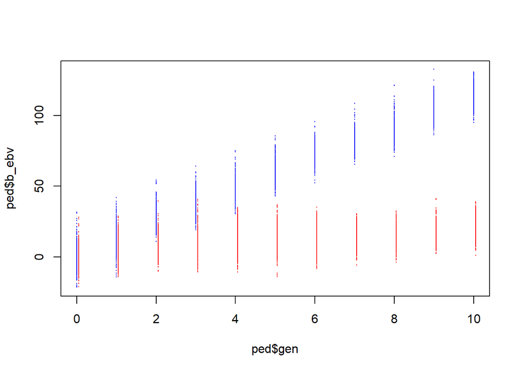

```r
plot(ped$gen,ped$b_ebv, col="blue", cex =0.1)
points(ped$gen+0.05,ped$f_ebv,col="red", cex=0.1)
```

Regress the EBVs against generation to estimate gains per generation. I am assuming a simple linear trend here. `bwt` shows strong gain in response to selection upon it, `fwt` shows weak positive gain. These predicted gains are in line with the signs of the genetic correlations (not surprisingly).

```r
summary(lm(ped$b_ebv~1+ped$gen))
summary(lm(ped$f_ebv~1+ped$gen))
```

```
##
## Call:
## lm(formula = ped$b_ebv ~ 1 + ped$gen)
##
## Residuals:
##      Min       1Q   Median       3Q      Max
## -29.4877  -4.7384  -0.1165   4.4917  28.4717
##
## Coefficients:
##             Estimate Std. Error t value Pr(>|t|)
## (Intercept)   3.9528     0.2112   18.71   <2e-16 ***
## ped$gen      11.1052     0.0357  311.06   <2e-16 ***
## ---
## Signif. codes:  0 '***' 0.001 '**' 0.01 '*' 0.05 '.' 0.1 ' ' 1
##
## Residual standard error: 7.489 on 4398 degrees of freedom
## Multiple R-squared:  0.9565, Adjusted R-squared:  0.9565
## F-statistic: 9.676e+04 on 1 and 4398 DF,  p-value: < 2.2e-16
##
##
## Call:
## lm(formula = ped$f_ebv ~ 1 + ped$gen)
##
## Residuals:
##     Min      1Q  Median      3Q     Max
## -25.821  -5.857  -0.245   5.536  32.496
##
## Coefficients:
##             Estimate Std. Error t value Pr(>|t|)
## (Intercept)  3.66508    0.23535   15.57   <2e-16 ***
## ped$gen      1.63077    0.03978   40.99   <2e-16 ***
## ---
## Signif. codes:  0 '***' 0.001 '**' 0.01 '*' 0.05 '.' 0.1 ' ' 1
##
## Residual standard error: 8.345 on 4398 degrees of freedom
## Multiple R-squared:  0.2765, Adjusted R-squared:  0.2763
## F-statistic:  1680 on 1 and 4398 DF,  p-value: < 2.2e-16
```

Replot …

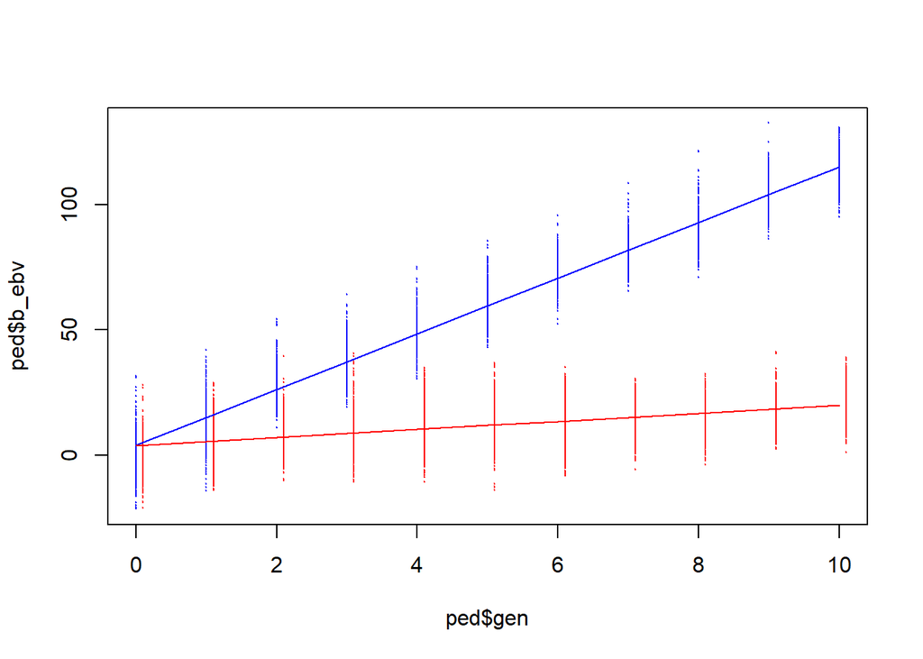

```r
plot(ped$gen,ped$b_ebv, col="blue", cex =0.1)
points(ped$gen+0.1,ped$f_ebv,col="red", cex=0.1)
lines(ped$gen, 3.95+11.11*ped$gen, col="blue")
lines(ped$gen, 3.67+ 1.63*ped$gen, col="red")
```

## 8.4 A note on the correlations among EBVs

Note that correlations among EBVs are NOT estimates of the genetic correlations unless the accuracy of all the EBVs are really close to 1! If the accuracies are poor, they are often very different from the true genetic correlations and should always be treated as such!

```r
cor(ped[,c("b_ebv","f_ebv")])
```

```
##          b_ebv    f_ebv
## b_ebv 1.000000 0.529704
## f_ebv 0.529704 1.000000
```

It is very different from the correct estimate! This is because the EBV correlations depend on the information used to estimate the EBVs, do not properly account for the sampling correlations, and individuals will have different amounts of information.

# 9 Testing hypotheses on genetic correlations

It is unusual to carry out a formal LRT with a null hypothesis that $V_a$ = 0 for a trait within a multi-trait analysis, although it can be done. For one reason, if it is difficult to detect genetic variance in a trait, then it is doubly difficult to detect if this variation is associated with genetic variation in another trait, which may also be estimated with uncertainty. Typically, particularly with pedigree, you need an order of magnitude more data to get a reliable genetic correlation than you do to get a reliable heritability. Therefore the existence of the genetic variance in the traits is often already established.

The typical hypotheses arising from multi-trait analysis are concerned with whether or not there is evidence that the genetic correlations are 0, i.e. whether the traits can be regarded as genetically independent. The hypotheses being tested are a Null H0: $r_A$ = 0 against an Alternative H1: $r_A$ < or > 0 i.e. not equal to 0. This test is done by LRT, but note that H0 is not on a boundary as the bounds of $r_A$ are -1 and 1. Therefore we can follow steps (1) to (4) as in Tutorial 3 but step (5) is now simply determined by standard comparisons to chi-squared tables e.g. for Type 1 error of 0.05 (i.e. P<0.05) compare to the 95% point of chi-squared with 1 d.f. (`qchisq(0.95,1)` = 3.841).

- Step (1) is the full model fitted above - it had a log likelihood, logL1 = -32570.73
- Step (2) is fitting the reduced model.
  - The hypotheses being tested are equivalent to H0: genetic covariance $V_a$[1,2] = 0 against the alternative H1: genetic covariance $V_a$[1,2] < or > 0.
  - This can be simply achieved by changing the variance model for the traits from `us(trait):vm(id,ainv)` to `idh(trait):vm(id,ainv)` which models the genetic (co)variances as a diagonal matrix, so all (co)variances are 0.
  - So the following code carries out Step (2) with logL0 = -32574.31.

```r
tut4.red <- asreml(fixed=cbind(bwt,fwt)~trait+trait:sex+trait:tank+trait:period,random=~idh(trait):vm(id,ainv),residual=~id(units):us(trait),data=tut4)
qgm_summary(tut4.red)
```

```
## [1] "CONVERGENCE: TRUE with logL = -32574.306155506"
##
## [1] "VARIANCE COMPONENTS"
##
##
## |                             | component| std.error|   z.ratio|bound | %ch|
## |:----------------------------|---------:|---------:|---------:|:-----|---:|
## |trait:vm(id, ainv)!trait_bwt |  177.0297| 19.683456|  8.993833|P     |   0|
## |trait:vm(id, ainv)!trait_fwt |  188.4403| 28.286666|  6.661808|P     |   0|
## |units:trait!R                |    1.0000|        NA|        NA|F     |   0|
## |units:trait!trait_bwt:bwt    |  413.6848| 13.977370| 29.596754|P     |   0|
## |units:trait!trait_fwt:bwt    |  184.6325|  9.738449| 18.959130|P     |   0|
## |units:trait!trait_fwt:fwt    |  647.4183| 21.459069| 30.169915|P     |   0|
##
## [1] "FIXED EFFECTS"
##
##
## |                    |    solution| std error|     z.ratio|
## |:-------------------|-----------:|---------:|-----------:|
## |trait_bwt           | 142.7676785| 1.7698748|  80.6654131|
## |trait_fwt           | 143.5454039| 2.1194271|  67.7284001|
## |trait_bwt:sex_1     |   0.0000000|        NA|          NA|
## |trait_bwt:sex_2     |   7.4930516| 0.6738650|  11.1195138|
## |trait_fwt:sex_1     |   0.0000000|        NA|          NA|
## |trait_fwt:sex_2     | -12.8293242| 0.8199377| -15.6467069|
## |trait_bwt:tank_1    |   0.0000000|        NA|          NA|
## |trait_bwt:tank_2    |   6.3620216| 0.9624163|   6.6104675|
## |trait_bwt:tank_3    |  -7.5328114| 0.9653907|  -7.8028627|
## |trait_bwt:tank_4    |  -3.4424546| 0.9646182|  -3.5687225|
## |trait_fwt:tank_1    |   0.0000000|        NA|          NA|
## |trait_fwt:tank_2    |   6.4243041| 1.1707138|   5.4875103|
## |trait_fwt:tank_3    |  -8.8792742| 1.1742760|  -7.5614882|
## |trait_fwt:tank_4    |   6.0902944| 1.1729025|   5.1924985|
## |trait_bwt:period_0  |   0.0000000|        NA|          NA|
## |trait_bwt:period_1  |  -0.1755741| 2.1347518|  -0.0822457|
## |trait_bwt:period_2  |  -0.6813742| 2.4953139|  -0.2730615|
## |trait_bwt:period_3  |  -0.7140282| 2.8674400|  -0.2490124|
## |trait_bwt:period_4  |  -0.7951548| 3.1838515|  -0.2497462|
## |trait_bwt:period_5  |  -3.2287057| 3.4627345|  -0.9324150|
## |trait_bwt:period_6  |  -0.3849498| 3.7315910|  -0.1031597|
```

[output cut: 12 more lines]

```
## |trait_fwt:period_7  |   5.7611003| 4.6787789|   1.2313256|
## |trait_fwt:period_8  |   7.1871563| 4.9295639|   1.4579700|
## |trait_fwt:period_9  |   7.4036408| 5.1850066|   1.4278942|
## |trait_fwt:period_10 |  11.0408766| 5.4389519|   2.0299640|
## |trait_fwt:period_11 |   9.9200424| 5.7735662|   1.7181829|
##
## [1] "WALD TESTS"
##
##
## |             | Df|  denDF|     F.con|Pr     |
## |:------------|--:|------:|---------:|:------|
## |trait        |  2| 1447.1| 11700.000|0.0000 |
## |trait:sex    |  2| 4259.7|   261.500|0.0000 |
## |trait:tank   |  6| 5706.6|    63.590|0.0000 |
## |trait:period | 22| 5844.6|     1.044|0.4043 |
```

- Step (3) calculates the test statistic of 2x(32574.31-32570.73) = 7.16.
- Steps (4) and (5) are comparing to chi-squared with 1 d.f. Below the critical values show that is the Type 1 error was 0.05 or 0.01 then there is sufficient evidence to reject H0 for a non-zero genetic correlation, but not if the Type 1 error was set to 0.001.

```r
qchisq(0.95,1)
```

```
## [1] 3.841459
```

```r
qchisq(0.99,1)
```

```
## [1] 6.634897
```

```r
qchisq(0.999,1)
```

```
## [1] 10.82757
```

## 9.1 Question 11

- Q11. Test the Null hypothesis H0: $r_E$ = 0 with an Alternative H1: $r_E$ < or > 0 with Type 1 error = 0.05.
- $\mathbf{Answer.}$ The test statistic is twice the drop in log-likelihood by fixing the correlation to 0 as stated in H0. The correlation can be set to zero by replacing the `us(trait)` in the residual with `idh(trait)`. This estimates parameters assuming the trait’s genetic (co)variance matrix to be (v11 0 | 0 v22) instead of (v11 v | v v22). The value of the test statistic is 164.39. The critical value is `qchisq(0.95,1)` = 3.841 - note this component is not on a boundary as it can be negative or positive! So H0 can be rejected in favour of H1, with P<0.001.

```r
tut4.red <- asreml(fixed=cbind(bwt,fwt)~trait+trait:sex+trait:tank+trait:period,random=~us(trait):vm(id,ainv),residual=~id(units):idh(trait),data=tut4)
qgm_summary(tut4.red)
```

```
## [1] "CONVERGENCE: TRUE with logL = -32652.9239591267"
##
## [1] "VARIANCE COMPONENTS"
##
##
## |                                 | component| std.error|  z.ratio|bound | %ch|
## |:--------------------------------|---------:|---------:|--------:|:-----|---:|
## |trait:vm(id, ainv)!trait_bwt:bwt |  308.1219|  24.27420| 12.69339|P     | 0.0|
## |trait:vm(id, ainv)!trait_fwt:bwt |  257.6814|  17.97301| 14.33713|P     | 0.1|
## |trait:vm(id, ainv)!trait_fwt:fwt |  421.4929|  38.30767| 11.00283|P     | 0.1|
## |units:trait!R                    |    1.0000|        NA|       NA|F     | 0.0|
## |units:trait!trait_bwt            |  346.2883|  13.51498| 25.62255|P     | 0.0|
## |units:trait!trait_fwt            |  521.3028|  21.39957| 24.36043|P     | 0.0|
##
## [1] "FIXED EFFECTS"
##
##
## |                    |   solution| std error|     z.ratio|
## |:-------------------|----------:|---------:|-----------:|
## |trait_bwt           | 143.304642| 1.8224544|  78.6327739|
## |trait_fwt           | 144.611000| 2.1933941|  65.9302399|
## |trait_bwt:sex_1     |   0.000000|        NA|          NA|
## |trait_bwt:sex_2     |   7.534897| 0.6693987|  11.2562176|
## |trait_fwt:sex_1     |   0.000000|        NA|          NA|
## |trait_fwt:sex_2     | -12.767260| 0.8102148| -15.7578696|
## |trait_bwt:tank_1    |   0.000000|        NA|          NA|
## |trait_bwt:tank_2    |   6.343186| 0.9515446|   6.6661988|
## |trait_bwt:tank_3    |  -7.608625| 0.9543083|  -7.9729210|
## |trait_bwt:tank_4    |  -3.446785| 0.9543859|  -3.6115207|
## |trait_fwt:tank_1    |   0.000000|        NA|          NA|
## |trait_fwt:tank_2    |   6.418539| 1.1522170|   5.5705995|
## |trait_fwt:tank_3    |  -9.044692| 1.1555768|  -7.8269930|
## |trait_fwt:tank_4    |   6.035744| 1.1555045|   5.2234706|
## |trait_bwt:period_0  |   0.000000|        NA|          NA|
## |trait_bwt:period_1  |  -2.970700| 2.1941612|  -1.3539117|
## |trait_bwt:period_2  |  -6.746091| 2.5506410|  -2.6448610|
## |trait_bwt:period_3  |  -8.813135| 2.9368307|  -3.0008998|
## |trait_bwt:period_4  | -10.894200| 3.2580051|  -3.3438253|
## |trait_bwt:period_5  | -14.374094| 3.5510539|  -4.0478389|
## |trait_bwt:period_6  | -13.286155| 3.8334369|  -3.4658598|
```

[output cut: 12 more lines]

```
## |trait_fwt:period_7  | -32.392079| 4.9293574|  -6.5712579|
## |trait_fwt:period_8  | -35.594215| 5.2106029|  -6.8311126|
## |trait_fwt:period_9  | -40.296905| 5.4862744|  -7.3450400|
## |trait_fwt:period_10 | -41.974816| 5.7527640|  -7.2964606|
## |trait_fwt:period_11 | -45.534849| 6.0839844|  -7.4843797|
##
## [1] "WALD TESTS"
##
##
## |             | Df|  denDF|    F.con|Pr     |
## |:------------|--:|------:|--------:|:------|
## |trait        |  2| 1305.0| 8352.000|0.0000 |
## |trait:sex    |  2| 4550.3|  233.100|0.0000 |
## |trait:tank   |  6| 6021.0|   68.650|0.0000 |
## |trait:period | 22| 6164.0|    4.013|0.0000 |
```

The test statistic is 2x(32652.9239-32570.7309) = 164.39

# 10 Accuracies

Accuracy is directly related to genetic gain! See the additional pdf on ‘The Breeders Equation’! As covered in the lectures we can obtain estimates of accuracy by looking at the s.e. for each EBV and calculating $\sqrt{1 - (s.e.)^2/[(1+F)V_a]}$ where F is the inbreeding coefficient. These accuracies are useful and widely used but assume $\textit{(i) the model is correct and (ii) the estimated parameters are correct}$!

- F is one of the ‘attributes’ of the `ainv` created above, and can be obtained by `ped$f <- attr(ainv,"inbreeding")`.
- The leading diagonal of $\mathbf{A}$ tells us the genetic variance of the EBV for individual i relative to the base is $(1+F_i)V_a$.
- The $(s.e.)^2$ squared is that part of this genetic variance unexplained by our model, called the Prediction Error Variance, so the amount explained is $(1+F_i)V_a - (s.e.)^2$
- The fraction of variance explained i.e. $1- (s.e.)^2/[(1+F_i)V_a]$ is the squared correlation
- So the accuracy for individual i, which is the correlation, is $\sqrt{1 - (s.e.)^2/[(1+F)V_a]}$

The estimates of $V_a$ for each trait are taken from the bi-variate analysis.

```r
ped$f <- attr(ainv,"inbreeding")
bva <- 189.06
fva <- 207.36
ped$b_acc <- sqrt(1. - ped$b_se**2./(bva*(1+ped$f)))
ped$f_acc <- sqrt(1. - ped$f_se**2./(fva*(1+ped$f)))
head(ped[,c("b_acc","f_acc")])
```

```
##       b_acc     f_acc
## 1 0.8548040 0.8239886
## 2 0.5646043 0.4948519
## 3 0.5644228 0.4946475
## 4 0.5644098 0.4946357
## 5 0.5644045 0.4946305
## 6 0.7210629 0.6641382
```

```r
tail(ped[,c("b_acc","f_acc")])
```

```
##          b_acc     f_acc
## 4395 0.7835542 0.7525386
## 4396 0.7835720 0.7525547
## 4397 0.7828264 0.7518354
## 4398 0.7836546 0.7526371
## 4399 0.7836362 0.7526205
## 4400 0.7828427 0.7518504
```

Accuracies will differ among individuals according to the information available. A mean accuracy for generation 0 for `bwt` can be obtained by the following code.

```r
mean(ped[ped$gen %in% c(0),"b_acc"])
```

```
## [1] 0.5929347
```

## 10.1 Questions 12 to 15

- Q12. In generation 0, why are the accuracies of individuals 1, 2, and 6 different?
- $\mathbf{Answer.}$ Information! Generation 0 will have some individuals with recorded offspring, some with more than others, and some unselected with no offspring only their own phenotype: 1 is a sire, 6 is a dam, 2 is unselected.
- Q13. What is the information available for individual 2 upon which the EBV is based?
- $\mathbf{Answer.}$ As it is the base generation it is just its own phenotypes. In this multi-trait example, the traits not completely independent so information on one trait can help to predict the breeding value of another.
- Q14. In general, what is the accuracy of an individual for which the only information available is a phenotype of heritability $h^2$? Compare this to your answer to Q12.
- $\mathbf{Answer.}$ The answer is $h$. Since $h_2$ = 0.317 or 0.246, suggesting accuracies of 0.563 and 0.496. See the breeders equation pdf. Comparing the answers to Q12, in this example the second trait does not add very much information but this is not always the case! There is also some small rounding errors evident c.f. individuals 3, 4 and 5.
- Q15. How do the mean accuracies vary over generations?
- $\mathbf{Answer.}$ They increase over generations - there is a gradual increase in information on individuals in this constant structure. The change is faster at the beginning when the Bulmer effect - linkage disequilibrium arising from selection - arrives at a steady state. It will never be completely constant as inbreeding will change the genetic variance and heritability over time.

```r
acc <- data.frame(gen=numeric(11), b_acc=numeric(11), f_acc=numeric(11))
for (i in c(1:11)) {
   acc[i,1] <- i-1
   acc[i,2] <- mean(ped[ped$gen %in% c(i-1),"b_acc"])
   acc[i,3] <- mean(ped[ped$gen %in% c(i-1),"f_acc"])
}
acc
```

```
##    gen     b_acc     f_acc
## 1    0 0.5929347 0.5263572
## 2    1 0.7209677 0.6799188
## 3    2 0.7338448 0.6974347
## 4    3 0.7551573 0.7220693
## 5    4 0.7576249 0.7246619
## 6    5 0.7643942 0.7319692
## 7    6 0.7689573 0.7368499
## 8    7 0.7759835 0.7444075
## 9    8 0.7763052 0.7443369
## 10   9 0.7876278 0.7567951
## 11  10 0.7826601 0.7515303
```

# 11 Finally …

1. This data was created by simulation, so the true model is known:
   - there is no environmental trend over generations for any trait;
   - $h^2$ = 0.3 for all traits;
   - for `bwt` and `fwt` $r_A$ = $r_E$ = 0.3, `minl` was independent of both;
   - selection was only on `bwt` carried out using simple mass selection;
   - in the analysis of the data the estimate of $r_A$ between `bwt` and `fwt` was at the low end of what may be expected by chance;
   - fitting the environmental trend (`period` in our model) is important (and essential in real data) and why laboratory experiments, particularly those with discrete generations, benefit from control lines as environmental trends are more easily discerned;
   - although VERY important in all branches of quantitative genetics the challenge of estimating genetic correlations from pedigrees in real data should not be underestimated!
2. An alternative to using `us(trait)` is `corgh(trait)`.
3. In the above we have fitted the same model to all the traits in the analysis. However `asreml()` can fit different terms to each trait using the `at()` function. While this is quite simple to implement it is beyond the scope of QGM.

## 11.1 Questions 16 to 20

- Q16. Use `corgh(trait)` instead of `us(trait)` in the full bi-variate model that was fitted above. What does it do?
- $\mathbf{Answer.}$ It fits the same model as `us(trait)` but parameterises it differently. So instead of estimating covariances, it estimates the correlations. This can be useful, sometimes because the correlations are calculated directly, sometimes the different parameterisation can help convergence in fitting very complex models.
- Q17. How might one confirm that `corgh(trait)` is equivalent to using `us(trait)` when fitting the model?
- $\mathbf{Answer.}$ First check is the log-likelihood, since the models are equivalent then at convergence the likelihoods will be the same, and one should expect the variances to be the same. Since the fitting process uses a different set of parameters the sequence of log-likelihoods during convergenece will differ, and this may also lead to differences in estimates due to rounding errors, but these should be very small!

```r
# Q16
tut4.asr <- asreml(fixed=cbind(bwt,fwt)~trait+trait:sex+trait:tank+trait:period,random=~corgh(trait):vm(id,ainv),residual=~id(units):corgh(trait),data=tut4)
tut4.asr <- qgm_continue(tut4.asr,5,TRUE)
qgm_summary(tut4.asr)
```

```
## [1] "CONVERGENCE: TRUE with logL = -32570.7303883139"
##
## [1] "VARIANCE COMPONENTS"
##
##
## |                                            |   component|  std.error|   z.ratio|bound | %ch|
## |:-------------------------------------------|-----------:|----------:|---------:|:-----|---:|
## |trait:vm(id, ainv)!trait!fwt:!trait!bwt.cor |   0.2262132|  0.0849799|  2.661962|U     |   0|
## |trait:vm(id, ainv)!trait_bwt                | 189.0610494| 21.1310629|  8.947068|P     |   0|
## |trait:vm(id, ainv)!trait_fwt                | 207.3600255| 30.6815434|  6.758461|P     |   0|
## |units:trait!R                               |   1.0000000|         NA|        NA|F     |   0|
## |units:trait!trait!fwt:!trait!bwt.cor        |   0.3204184|  0.0223706| 14.323191|U     |   0|
## |units:trait!trait_bwt                       | 406.9684134| 14.3589940| 28.342404|P     |   0|
## |units:trait!trait_fwt                       | 636.7843916| 22.0931978| 28.822645|P     |   0|
##
## [1] "FIXED EFFECTS"
##
##
## |                    |    solution| std error|     z.ratio|
## |:-------------------|-----------:|---------:|-----------:|
## |trait_bwt           | 142.7336927| 1.7756592|  80.3834957|
## |trait_fwt           | 143.6467940| 2.1269512|  67.5364780|
## |trait_bwt:sex_1     |   0.0000000|        NA|          NA|
## |trait_bwt:sex_2     |   7.4996436| 0.6732449|  11.1395482|
## |trait_fwt:sex_1     |   0.0000000|        NA|          NA|
## |trait_fwt:sex_2     | -12.8199606| 0.8190999| -15.6512790|
## |trait_bwt:tank_1    |   0.0000000|        NA|          NA|
## |trait_bwt:tank_2    |   6.3621445| 0.9619734|   6.6136390|
## |trait_bwt:tank_3    |  -7.5535595| 0.9649951|  -7.8275627|
## |trait_bwt:tank_4    |  -3.4422144| 0.9643269|  -3.5695513|
## |trait_fwt:tank_1    |   0.0000000|        NA|          NA|
## |trait_fwt:tank_2    |   6.4213355| 1.1701398|   5.4876654|
## |trait_fwt:tank_3    |  -8.9158933| 1.1737747|  -7.5959151|
## |trait_fwt:tank_4    |   6.0803047| 1.1725410|   5.1855794|
## |trait_bwt:period_0  |   0.0000000|        NA|          NA|
## |trait_bwt:period_1  |  -0.5856761| 2.1471789|  -0.2727654|
## |trait_bwt:period_2  |  -1.7735983| 2.5213957|  -0.7034193|
## |trait_bwt:period_3  |  -2.1732428| 2.9014367|  -0.7490230|
## |trait_bwt:period_4  |  -2.5733332| 3.2242668|  -0.7981142|
## |trait_bwt:period_5  |  -5.2259617| 3.5105011|  -1.4886655|
```

[output cut: 13 more lines]

```
## |trait_fwt:period_7  |  -2.1070032| 4.7647474|  -0.4422067|
## |trait_fwt:period_8  |  -1.6655685| 5.0250298|  -0.3314544|
## |trait_fwt:period_9  |  -2.4387936| 5.2878254|  -0.4612092|
## |trait_fwt:period_10 |   0.0730367| 5.5479257|   0.0131647|
## |trait_fwt:period_11 |  -1.5367944| 5.8833954|  -0.2612088|
##
## [1] "WALD TESTS"
##
##
## |             | Df|  denDF|     F.con|Pr     |
## |:------------|--:|------:|---------:|:------|
## |trait        |  2| 1171.6| 1.072e+04|0.0000 |
## |trait:sex    |  2| 4260.5| 2.621e+02|0.0000 |
## |trait:tank   |  6| 5706.9| 6.381e+01|0.0000 |
## |trait:period | 22| 5665.1| 9.642e-01|0.5078 |
```

- Q18. Add a maternal effect to the full model using `idh(trait):dam`. What do you conclude?
- $\mathbf{Answer.}$ Maternal effects are very small in this data as the log-likelihood does not change! There is no evidence $V_d$ > 0. Note that typically one would initially add the term as `us(trait):dam`, or equivalently `corgh(trait):dam` to include the covariance, but here one trait has a bound maternal variance and is `NA`, which causes a problem when trying to fit the covariance! So the question offered the simpler model estimating only the two variances.

```r
# Q18
tut4.asr <- asreml(fixed= cbind(bwt,fwt)~trait+trait:sex+trait:tank+trait:period, random= ~corgh(trait):vm(id,ainv) + idh(trait):dam, residual= ~id(units):corgh(trait), data=tut4)
tut4.asr <- qgm_continue(tut4.asr,5,TRUE)
qgm_summary(tut4.asr)
```

```
## [1] "CONVERGENCE: TRUE with logL = -32570.727682327"
##
## [1] "VARIANCE COMPONENTS"
##
##
## |                                            |   component|  std.error|    z.ratio|bound | %ch|
## |:-------------------------------------------|-----------:|----------:|----------:|:-----|---:|
## |trait:dam!trait_bwt                         |   0.0000000|         NA|         NA|B     |  NA|
## |trait:dam!trait_fwt                         |   0.0000009|  0.0000093|  0.1008358|P     |   0|
## |trait:vm(id, ainv)!trait!fwt:!trait!bwt.cor |   0.2203669|  0.0904970|  2.4350751|U     |   0|
## |trait:vm(id, ainv)!trait_bwt                | 189.0465164| 21.1402398|  8.9424963|P     |   0|
## |trait:vm(id, ainv)!trait_fwt                | 206.6490033| 30.8386752|  6.7009689|P     |   0|
## |units:trait!R                               |   1.0000000|         NA|         NA|F     |   0|
## |units:trait!trait!fwt:!trait!bwt.cor        |   0.3216691|  0.0232736| 13.8212271|U     |   0|
## |units:trait!trait_bwt                       | 406.9767848| 14.3638024| 28.3334994|P     |   0|
## |units:trait!trait_fwt                       | 637.1813058| 22.1650585| 28.7471069|P     |   0|
##
## [1] "FIXED EFFECTS"
##
##
## |                    |    solution| std error|     z.ratio|
## |:-------------------|-----------:|---------:|-----------:|
## |trait_bwt           | 142.7351292| 1.7756404|  80.3851551|
## |trait_fwt           | 143.6459877| 2.1266918|  67.5443382|
## |trait_bwt:sex_1     |   0.0000000|        NA|          NA|
## |trait_bwt:sex_2     |   7.4995195| 0.6732448|  11.1393643|
## |trait_fwt:sex_1     |   0.0000000|        NA|          NA|
## |trait_fwt:sex_2     | -12.8186779| 0.8191400| -15.6489463|
## |trait_bwt:tank_1    |   0.0000000|        NA|          NA|
## |trait_bwt:tank_2    |   6.3621569| 0.9619653|   6.6137071|
## |trait_bwt:tank_3    |  -7.5534221| 0.9649865|  -7.8274897|
## |trait_bwt:tank_4    |  -3.4424161| 0.9643178|  -3.5697941|
## |trait_fwt:tank_1    |   0.0000000|        NA|          NA|
## |trait_fwt:tank_2    |   6.4222403| 1.1701759|   5.4882692|
## |trait_fwt:tank_3    |  -8.9135277| 1.1738126|  -7.5936547|
## |trait_fwt:tank_4    |   6.0791133| 1.1725749|   5.1844137|
## |trait_bwt:period_0  |   0.0000000|        NA|          NA|
## |trait_bwt:period_1  |  -0.5825174| 2.1471250|  -0.2713011|
## |trait_bwt:period_2  |  -1.7626337| 2.5213840|  -0.6990739|
## |trait_bwt:period_3  |  -2.1611750| 2.9019885|  -0.7447221|
```

[output cut: 15 more lines]

```
## |trait_fwt:period_7  |  -2.4707023| 4.9524614|  -0.4988837|
## |trait_fwt:period_8  |  -2.1073527| 5.2729515|  -0.3996533|
## |trait_fwt:period_9  |  -2.9476899| 5.5921611|  -0.5271111|
## |trait_fwt:period_10 |  -0.4901381| 5.9039668|  -0.0830184|
## |trait_fwt:period_11 |  -2.1220646| 6.2478252|  -0.3396485|
##
## [1] "WALD TESTS"
##
##
## |             | Df|  denDF|     F.con|Pr     |
## |:------------|--:|------:|---------:|:------|
## |trait        |  2| 1129.3| 1.074e+04|0.0000 |
## |trait:sex    |  2| 4256.6| 2.621e+02|0.0000 |
## |trait:tank   |  6| 5703.4| 6.380e+01|0.0000 |
## |trait:period | 22|  210.0| 9.093e-01|0.5829 |
```

- Q19. Run a bivariate model (ignoring maternal effects) for `bwt` and `minl`. What are the estimates of the genetic and residual correlations?
- $\mathbf{Answer.}$ Using `corgh()` these can be obtained directly: $r_A$ = 0.011 with s.e. 0.085, and $r_E$ = -0.001 with s.e. 0.025.

```r
# Q19
tut4.asr <- asreml(fixed= cbind(bwt,minl) ~trait+trait:sex+trait:tank+trait:period, random= ~corgh(trait):vm(id,ainv), residual= ~id(units):corgh(trait), data= tut4)
tut4.asr <- qgm_continue(tut4.asr,5,TRUE)
qgm_summary(tut4.asr)
```

```
## [1] "CONVERGENCE: TRUE with logL = -33841.0879567613"
##
## [1] "VARIANCE COMPONENTS"
##
##
## |                                             |   component|  std.error|    z.ratio|bound | %ch|
## |:--------------------------------------------|-----------:|----------:|----------:|:-----|---:|
## |trait:vm(id, ainv)!trait!minl:!trait!bwt.cor |   0.0111238|  0.0851907|  0.1305753|U     |   0|
## |trait:vm(id, ainv)!trait_bwt                 | 190.4657465| 21.2285159|  8.9721649|P     |   0|
## |trait:vm(id, ainv)!trait_minl                | 404.9143872| 53.0321851|  7.6352575|P     |   0|
## |units:trait!R                                |   1.0000000|         NA|         NA|F     |   0|
## |units:trait!trait!minl:!trait!bwt.cor        |  -0.0014037|  0.0253329| -0.0554109|U     |   0|
## |units:trait!trait_bwt                        | 406.1941322| 14.3724341| 28.2620278|P     |   0|
## |units:trait!trait_minl                       | 993.3806342| 36.1285937| 27.4956906|P     |   0|
##
## [1] "FIXED EFFECTS"
##
##
## |                     |    solution| std error|     z.ratio|
## |:--------------------|-----------:|---------:|-----------:|
## |trait_bwt            | 142.7079605| 1.7763863|  80.3361063|
## |trait_minl           | 608.9528778| 2.7269705| 223.3074659|
## |trait_bwt:sex_1      |   0.0000000|        NA|          NA|
## |trait_bwt:sex_2      |   7.5019205| 0.6731827|  11.1439596|
## |trait_minl:sex_1     |   0.0000000|        NA|          NA|
## |trait_minl:sex_2     | -18.8187319| 1.0401743| -18.0919031|
## |trait_bwt:tank_1     |   0.0000000|        NA|          NA|
## |trait_bwt:tank_2     |   6.3621135| 0.9619555|   6.6137294|
## |trait_bwt:tank_3     |  -7.5586884| 0.9649843|  -7.8329651|
## |trait_bwt:tank_4     |  -3.4396592| 0.9643289|  -3.5668943|
## |trait_minl:tank_1    |   0.0000000|        NA|          NA|
## |trait_minl:tank_2    |  17.4503523| 1.4863629|  11.7403044|
## |trait_minl:tank_3    |  24.8400666| 1.4910331|  16.6596345|
## |trait_minl:tank_4    |  -5.7205327| 1.4897977|  -3.8398051|
## |trait_bwt:period_0   |   0.0000000|        NA|          NA|
## |trait_bwt:period_1   |  -0.6561298| 2.1488192|  -0.3053444|
## |trait_bwt:period_2   |  -2.0014869| 2.5249460|  -0.7926850|
## |trait_bwt:period_3   |  -2.4182627| 2.9060455|  -0.8321489|
## |trait_bwt:period_4   |  -2.8332762| 3.2297529|  -0.8772424|
## |trait_bwt:period_5   |  -5.4279932| 3.5169728|  -1.5433708|
```

[output cut: 13 more lines]

```
## |trait_minl:period_7  | -15.4928729| 6.2021110|  -2.4979999|
## |trait_minl:period_8  | -10.3538330| 6.5488396|  -1.5810180|
## |trait_minl:period_9  | -11.1214303| 6.8946461|  -1.6130531|
## |trait_minl:period_10 |  -8.9266177| 7.2344031|  -1.2339121|
## |trait_minl:period_11 |  -7.2741397| 7.6620359|  -0.9493743|
##
## [1] "WALD TESTS"
##
##
## |             | Df|  denDF|     F.con|Pr     |
## |:------------|--:|------:|---------:|:------|
## |trait        |  2| 1262.4| 68440.000|0.0000 |
## |trait:sex    |  2| 4268.3|   225.800|0.0000 |
## |trait:tank   |  6| 5700.5|   129.700|0.0000 |
## |trait:period | 22| 6064.1|     1.085|0.3546 |
```

- Q20. [Optional] For experience, run the tri-variate model for `bwt`, `fwt` and `minl`.
- $\mathbf{Answer.}$ See below. The change in the command to get the trivariate is only in `cbind(bwt,fwt,minl)` but the number of parameters estimated increase greatly!

```r
# Q20
tut4.asr <- asreml(fixed= cbind(bwt,fwt,minl) ~trait+trait:sex+trait:tank+trait:period, random= ~corgh(trait):vm(id,ainv), residual= ~id(units):corgh(trait), data= tut4)
tut4.asr <- qgm_continue(tut4.asr,5,TRUE)
qgm_summary(tut4.asr)
```

```
## [1] "CONVERGENCE: TRUE with logL = -50441.1402519236"
##
## [1] "VARIANCE COMPONENTS"
##
##
## |                                             |   component|  std.error|    z.ratio|bound | %ch|
## |:--------------------------------------------|-----------:|----------:|----------:|:-----|---:|
## |trait:vm(id, ainv)!trait!fwt:!trait!bwt.cor  |   0.2266291|  0.0849880|  2.6666005|U     |   0|
## |trait:vm(id, ainv)!trait!minl:!trait!bwt.cor |   0.0088416|  0.0853375|  0.1036070|U     |   0|
## |trait:vm(id, ainv)!trait!minl:!trait!fwt.cor |  -0.0073987|  0.0984066| -0.0751852|U     |   0|
## |trait:vm(id, ainv)!trait_bwt                 | 189.0279905| 21.1304445|  8.9457650|P     |   0|
## |trait:vm(id, ainv)!trait_fwt                 | 207.2409042| 30.6762881|  6.7557360|P     |   0|
## |trait:vm(id, ainv)!trait_minl                | 404.6491821| 53.0215671|  7.6317846|P     |   0|
## |units:trait!R                                |   1.0000000|         NA|         NA|F     |   0|
## |units:trait!trait!fwt:!trait!bwt.cor         |   0.3203243|  0.0223699| 14.3194418|U     |   0|
## |units:trait!trait!minl:!trait!bwt.cor        |  -0.0008385|  0.0252942| -0.0331515|U     |   0|
## |units:trait!trait!minl:!trait!fwt.cor        |   0.0148687|  0.0250943|  0.5925131|U     |   0|
## |units:trait!trait_bwt                        | 406.9861637| 14.3593779| 28.3428826|P     |   0|
## |units:trait!trait_fwt                        | 636.8520428| 22.0934395| 28.8253914|P     |   0|
## |units:trait!trait_minl                       | 993.5287453| 36.1293631| 27.4992046|P     |   0|
##
## [1] "FIXED EFFECTS"
##
##
## |                     |    solution| std error|     z.ratio|
## |:--------------------|-----------:|---------:|-----------:|
## |trait_bwt            | 142.7340633| 1.7756445|  80.3843688|
## |trait_fwt            | 143.6455584| 2.1269065|  67.5373163|
## |trait_minl           | 608.9590705| 2.7268920| 223.3161644|
## |trait_bwt:sex_1      |   0.0000000|        NA|          NA|
## |trait_bwt:sex_2      |   7.4994242| 0.6732463|  11.1391983|
## |trait_fwt:sex_1      |   0.0000000|        NA|          NA|
## |trait_fwt:sex_2      | -12.8194803| 0.8191057| -15.6505812|
## |trait_minl:sex_1     |   0.0000000|        NA|          NA|
## |trait_minl:sex_2     | -18.8194299| 1.0401835| -18.0924126|
## |trait_bwt:tank_1     |   0.0000000|        NA|          NA|
## |trait_bwt:tank_2     |   6.3630622| 0.9619756|   6.6145776|
## |trait_bwt:tank_3     |  -7.5533730| 0.9649973|  -7.8273512|
## |trait_bwt:tank_4     |  -3.4419482| 0.9643290|  -3.5692678|
## |trait_fwt:tank_1     |   0.0000000|        NA|          NA|
```

[output cut: 38 more lines]

```
## |trait_minl:period_7  | -15.4004021| 6.2014378|  -2.4833599|
## |trait_minl:period_8  | -10.2527307| 6.5480920|  -1.5657585|
## |trait_minl:period_9  | -11.0139298| 6.8938425|  -1.5976474|
## |trait_minl:period_10 |  -8.8063262| 7.2335547|  -1.2174272|
## |trait_minl:period_11 |  -7.1343068| 7.6611814|  -0.9312280|
##
## [1] "WALD TESTS"
##
##
## |             | Df|  denDF|     F.con|Pr     |
## |:------------|--:|------:|---------:|:------|
## |trait        |  3| 1161.1| 47320.000|0.0000 |
## |trait:sex    |  3| 4256.8|   281.000|0.0000 |
## |trait:tank   |  9| 6718.3|   104.800|0.0000 |
## |trait:period | 33| 7631.2|     1.012|0.4490 |
```

# 12 Outcomes

We have covered:

- how to set up a multi-trait model in `asreml()`
- how to look at its output
- how to examine genetic trends
- how to test a Null Hypothesis H0: $r_A$ = 0 against and Alternative H1: not H0
- how to calculate accuracies
- some different options for modelling (co)variances between traits in `asreml()`